# HW2.1

```r
set.seed(1984)
```

In the posted homework solutions, there is a 20% chance that there is an error in the posted solutions. If an error is present, then the number of students who send emails about the error follows a poisson(3) distrubution.

*If no emails were recieved, what is the probability that there was no error*

#### We must first define our information

The probability of an error in the posted solutions is 20%  
$\therefore$ $prob.of.error.hw = P(E) = 0.20$

Also,  
$\therefore$ $prob.of.no.error.hw = P(E_c) = 0.80$

```r
set.seed(1984)
hw_errors <- function(n){
  num_of_emails.df <- data.frame() #Creation of Empty Data Frame
for(i in 1:n){x_ind <- 0 #Indicator Variable
  x_ind <- sample(c(0,1),1,replace = TRUE, prob = c(0.8,0.2)) #Probability of Error in HW
if(x_ind == 1){num_of_emails.df <- rbind(num_of_emails.df, rpois(1,3))}
} #If there is an error what is the number of emails received with
#respect to the poisson distrubution
no_emails_with_error <- sum(num_of_emails.df == 0) #Sum the number of 0 email occurances
return(no_emails_with_error/n) #Sum of the number of 0 emails weighted by the total
##number of HW Solutions posted
    }

#Therefore, the probability of an error being in the solutions, yet no email
#received about it, is about
(1 - hw_errors(50000))
```

```
## [1] 0.99042
```

# HW2.2

## Calculate P(X is odd) in each setting below.

1. X ~ Geometric(0.7)
2. X ~ Binomial(101, 0.5)
3. First let Y ~ N(0,1), and then let X be the answer you get when you round Y to the nearest integer.  
   ##################################################################################################################

#### a) X ~ Geometric(0.7)

```r
#Function to determine if number is odd
prob_geom_odd <- function(n, p){
geom.df <- data.frame(rgeom(n, p)) #Creation of a data frame with random draws
colnames(geom.df) <- c("Binary")
geom.binary.df <- (geom.df%%2!=0) #function to find the odd numbers
return(1-sum(geom.binary.df)/n) #returning the probability
}
prob_geom_odd(500000, 0.7)
```

```
## [1] 0.768722
```

$P(X is odd) = P(X = 1) + P(X = 3) + P(X = 5) + ... + P(X = i) = \sum_{k=1}^{\infty} q(1-p)^{2n-2} = (0.7)(1-0.7)^{0} + (0.7)(1-0.7)^{2} + ...$  
The sum of a geometric series is equal to…

$Sum = \frac{S_1}{1-r^{2}}$

$\therefore P(X~is~Odd) = \frac{0.7}{1-(0.3)^{2}} = \frac{0.7}{0.91}= 0.76923= 0.77$

#### b) Binomial(101, 0.5)

$P(X is odd) = P(X = 1) + P(X = 3) + P(X = 5) + ... + P(X = i)$

However, the probabilities are equal because there is an equal chance each draw: $P(X = 1) = P(X = 3) = P(X = 100)$

$\therefore P(X is Odd) = 0.5$

3. First let Y ~ N(0,1), and then let X be the answer you get when you round Y to the nearest integer.

We know that we are are sampling from the normal distrubution,

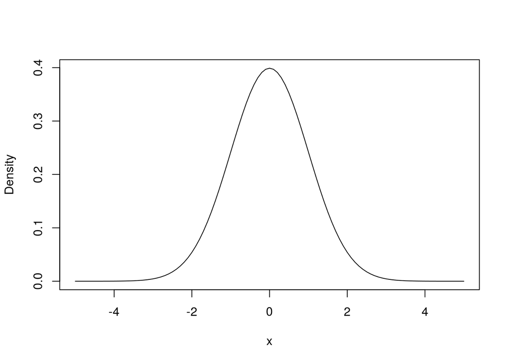

```r
curve(dnorm(x), from = -5, to = 5, ylab = "Density")
```

Which has a range of about -5 to 5 approximately. Thus is if we integrate between the areas which will not be rounded to an odd number we can take one minus that values to figure out the probability of getting an odd number.

$P(X is Odd) = 1- 2(\int_{0}^{0.5} \frac{1}{\sqrt{2\pi}}~e^{-\frac{x^{2}}{2}}~dx + \int_{1.5}^{2.5} \frac{1}{\sqrt{2\pi}}~e^{-\frac{x^{2}}{2}}~dx + \int_{3.5}^{4.5} \frac{1}{\sqrt{2\pi}}~e^{-\frac{x^{2}}{2}}~dx)$

```r
intergrand <- function(x){1/sqrt(2*pi)*exp(-(x^2/2))} #The pmf of the normal distrubution where N(0,1)

prob_0_0.5 <- integrate(intergrand, 0, 0.5) #from 0 to 0.5

prob_1.5_2.5 <- integrate(intergrand, 1.5, 2.5) #from 1.5 to 2.5

prob_3.5_4.5 <- integrate(intergrand, 3.5, 4.5) #from 3.5 to 4.5

#Prob of odd number

(1 - 2*(prob_0_0.5[["value"]] + prob_1.5_2.5[["value"]] + prob_3.5_4.5[["value"]]))
```

```
## [1] 0.4954215
```

# HW2.3

One person draws from a full deck while a second person draws from a deck only cotaining only red suit cards (meaning hearts and diamonds only). For these next problems, determine if the distrubution of X and Y are the same.

*X/Y are indicator variables for drawing a face card (in this case Ace, Jacks, Queens, and Kings) with no replacements.*

*X/Y are the number of face cards drawn from each respective deck without replacement if ten cards are drawn.*  
$P(X = 10) = \frac{16}{52} * \frac{15}{51} * \frac{14}{50} * \frac{13}{49} * ... * \frac{7}{42} * \frac{6}{43}$  
$P(Y = 10) < 0$ Since there is only 8 face cards in the red deck

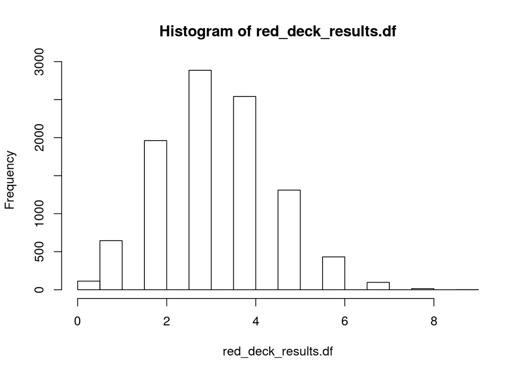

```r
library(data.table)
set.seed(1984)
    Face_card <- 1
      Non_face_card <- 0

data <- data.frame(red_deck = c(1, 1, 1, 1, 1, 1 ,1, 1, 0 , 0, 0, 0, 0, 0, 0, 0, 0, 0, 0, 0, 0, 0, 0, 0), full_deck = c(1, 1, 1, 1, 1, 1 ,1, 1, 0 , 0, 0, 0, 0, 0, 0, 0, 0, 0, 0, 0, 0, 0, 0, 0, 1, 1, 1, 1, 1, 1 ,1, 1, 0 , 0, 0, 0, 0, 0, 0, 0, 0, 0, 0, 0, 0, 0, 0, 0))


red_deck_draw <- function(reps){data.frame(red_deck = replicate(reps, {data.frame(red_deck_sample = sample(data$red_deck, 10, replace = FALSE))}))
}

red_deck_results.df  <- colSums(data.frame(red_deck_draw(10000)))


full_deck_draw <- function(reps){
  data.frame(full_deck = replicate(reps, {data.frame(full_deck_sample = sample(data$full_deck, 10, replace = FALSE))}))
}

full_deck_results.df <- colSums(data.frame(full_deck_draw(10000)))

#Histogram of Red Deck Distrubution
hist(red_deck_results.df)
```

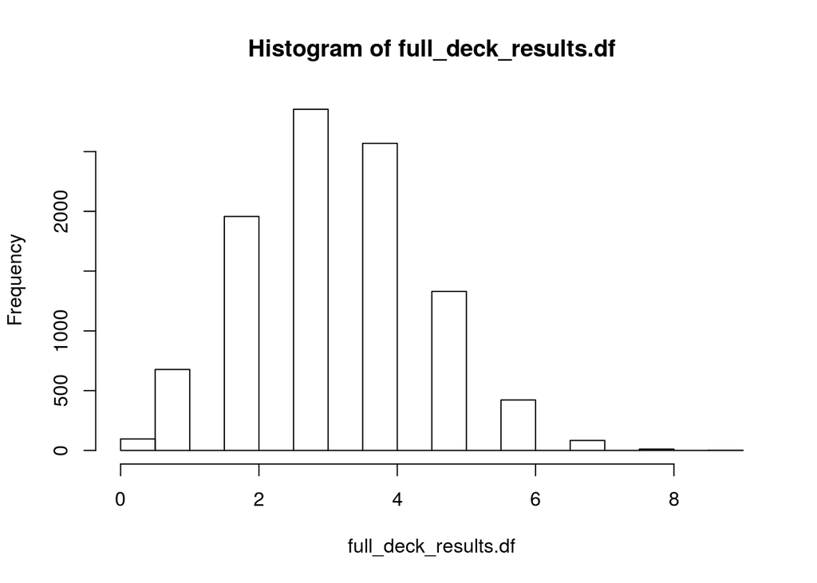

```r
#Histogram of Full Deck Distrubution
hist(full_deck_results.df)
```